# 11_week slides

## Week 11: Classes and Object-oriented Programming

### POP77001 Computer Programming for Social Scientists

### Tom Paskhalis

##### 21 November 2022

##### Module website: tinyurl.com/POP77001

## Overview

- Abstraction and decomposition
- Object attributes
- Object-oriented programming (OOP)
- Classes
- Methods
- Class inheritance

## Recap: Python conceptual hierarchy

Python programs can be decomposed into modules, statements, expressions, and objects, as follows:

1. **Programs** are composed of **modules**.
2. **Modules** contain **statements**.
3. **Statements** contain **expressions**
4. **Expressions** create and process **objects**.

## Recap: Python objects

- Everything that Python operates on is an **object**.
- This includes numbers, strings, data structures, functions, etc.
- Eact object has a **type** (e.g. string or function) and internal **data**.
- Objects can be **mutable** (e.g. list) and **immutable** (e.g. string).

## Recap: Decomposition and Abstraction

Source: [IKEA](https://www.ikea.com/us/en/cat/kallax-series-27534/)

## Achieving Decomposition and Abstraction

- So far: modules, functions.
- But modules and functions only abstract **code**.
- Not **data**.
- Hence, we need something else.
- **Classes**!

## Abstraction

[figure not shown]

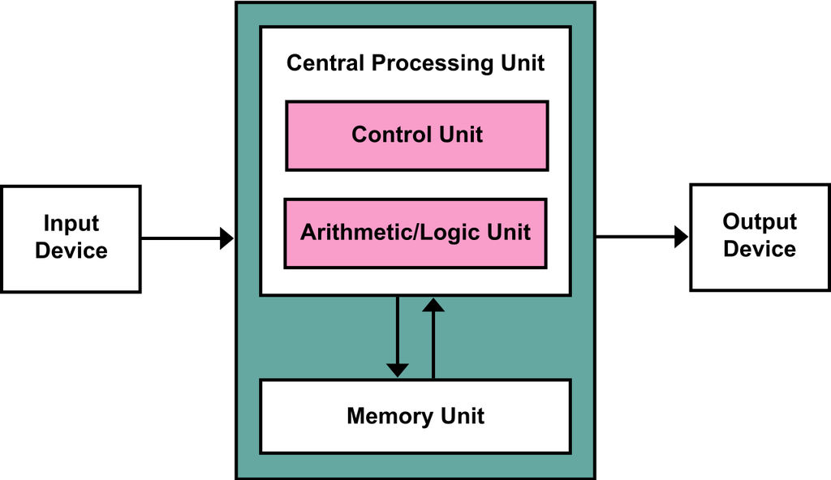

Source: [Gallerie dell'Accademia](https://gallerieaccademia.it/en/study-proportions-human-body-known-vitruvian-man), [Wikipedia](https://en.wikipedia.org/wiki/Von_Neumann_architecture)

## Python objects we have seen so far

- Built-in types (integers, strings, lists, etc.)
- Imported from external packages (arrays, data frames, etc.)

```python
s = 'watermelon'
sr = pd.Series([7, 1, 19])
```

Note the syntactic similarity between the two lines below:

```python
s.upper
```

```
<function str.upper()>
```

```python
sr.shape
```

```
(3,)
```

## Python object attributes

- Attributes are objects that are associated with a specific type.
- The constitute the essence of object-oriented programming in Python.

```
object.attribute
```

- This expression effectively means:

> Find the first occurrence of attribute by looking in `object`, then in all classes above it.

## Object-based vs Object-oriented programming

- Until now our code was **object-based**.
- We created and passed objects around our programs.
- For our code to be truly **object-oriented**,
- Our objects need to be part of **inheritance hierarchy**.

## Procedural vs Object-oriented programming

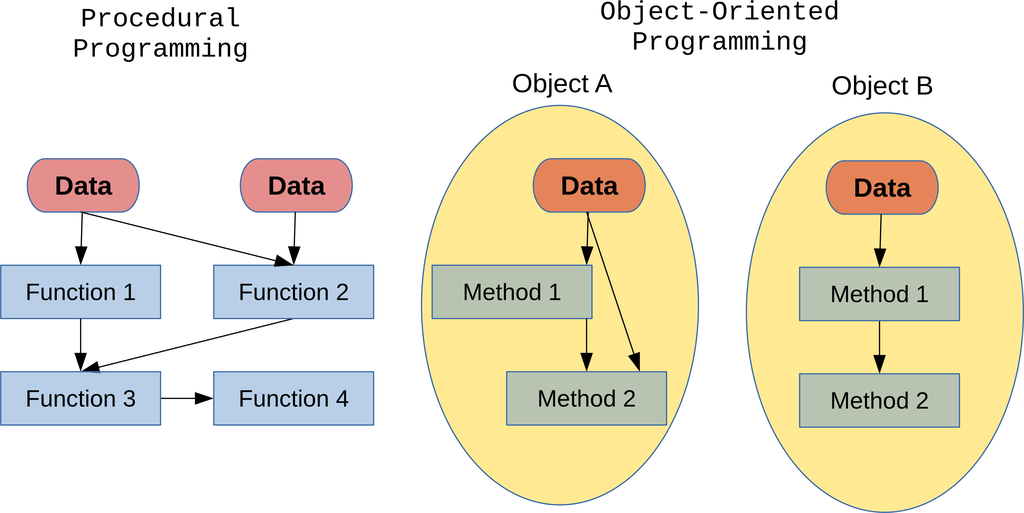

[figure not shown]

Source: [Wellcome Collection](https://wellcomecollection.org/articles/WsT4Ex8AAHruGfWb)  
Extra: [The Rise of Virtual Pets](https://www.youtube.com/watch?v=g30wI8Jc4Y0)

## Class definition

```python
from datetime import date

class Tamagotchi(object):
    """Creates a new Tamagotchi and gives it a name"""
    def __init__(self, name, birthdate = date.today()):
        self.name = name
        self.birthdate = birthdate
        self.food = 0
    def get_age(self):
        """Get Tamagotchi's name in days"""
        return date.today() - self.birthdate
    def feed(self):
        """Give Tamagotchi some food"""
        self.food += 1
    def play(self):
        """Play with Tamagotchi"""
        self.food -= 1
    def __str__(self):
        return (self.name + ' - ' +
                'Age: ' + str(self.get_age().days) + ' days ' +
                'Food: ' + str(self.food))
```

## Class definition explained

- Class: `Tamagotchi`
- Data attributes:
  - `name` - name given as string
  - `birthdate` - birth date expressed as `datetime.date`
  - `food` - food level expressed as integer
- Methods (functions attached to this class):
  - `__init__()` - constructor, called when an object of this class is created.
  - `__str__()` - called when an object of this class is printed (with `print()` or `str()`)
  - `get_age()` - retrieve age expressed as `datetime.timedelta`
  - `feed()` - increment food level by 1
  - `play()` - decrement food level by 1

## Class instantiation

```python
kuchipatchi = Tamagotchi("Kuchipatchi", date(2022, 5, 18))
```

```python
type(kuchipatchi) # Check object type
```

```
__main__.Tamagotchi
```

```python
kuchipatchi.name # Access object's data attribute
```

```
'Kuchipatchi'
```

```python
kuchipatchi.feed() # Invoke object method
```

```python
print(kuchipatchi)
```

```
Kuchipatchi - Age: 187 days Food: 1
```

## What is class?

- Classes are factories for generating one or more objects of the same type.
- Every time we call (instantiate) a class we create a new object (instance) with distinct namespace.

```python
mimitchi = Tamagotchi("Mimitchi", date(2022, 8, 8))
print(type(mimitchi))
print(mimitchi)
```

```
<class '__main__.Tamagotchi'>
Mimitchi - Age: 105 days Food: 0
```

```python
sebiretchi = Tamagotchi("Sebiretchi", date(2022, 11, 1))
print(type(sebiretchi))
print(sebiretchi)
```

```
<class '__main__.Tamagotchi'>
Sebiretchi - Age: 20 days Food: 0
```

## Classes vs Objects

- In our example above `Tamagotchi` is a class.
- `Kuchipatchi`, `Mimitchi`, `Sebiretchi` are instances of the class `Tamagotchi`.
- In other words, they are objects of type `Tamagotchi`.
- The same way as `str` is a class and `'watermelon'` is an object of type `str`.

## Class methods

- Functions associated with a specific class are called **methods**.
- These functions are simultaneously class attributes.
- Hence, their syntax is `object.method()` as opposed to `function(object)`.

```python
print(kuchipatchi)
print(mimitchi)
```

```
Kuchipatchi - Age: 187 days Food: 1
Mimitchi - Age: 105 days Food: 0
```

```python
kuchipatchi.feed() # Invoke object method
```

```python
# Methods modify only the data attritubes
# of the associated object
print(kuchipatchi)
print(mimitchi)
```

```
Kuchipatchi - Age: 187 days Food: 2
Mimitchi - Age: 105 days Food: 0
```

## Special methods

- Some methods start and end with double underscore (`__`).
- These methods serve special purposes.
- Usually, they are not expected to be invoked directly.
- Examples of special methods:
  - `__init__()` - defines object instantiation;
  - `__str__()` - defines how an object is printed out;
  - `__add__()` - overloads the `+` operator
    - also `__sub__()` for `-`, `__mul__()` for `*`, etc.
  - `__eq__()` - overloads the `==` operator
    - also `__lt__()` for `<`, `__ge__()` for `>=`, etc.
  - `__len__()` - returns the length of the object (is called by `len()` function)
  - `__iter__()` - returns an iterator (used in loops)

Extra: [Special method names](https://docs.python.org/3/reference/datamodel.html#special-method-names)

## `self`

- Variable that references the current instance of the class.
- The name is a convention, but a strong one.

```
def __init__(self, name):
    self.name = name
```

## Overloading

- Classes may override most built-in operators
- E.g. function `sorted()` requires `__lt__()` (less than) method to be implemented.

```python
class Tamagotchi(object):
    """Creates a new Tamagotchi and gives it a name"""
    def __init__(self, name, birthdate = date.today()):
        self.name = name
        self.birthdate = birthdate
        self.food = 0
    def get_age(self):
        """Get Tamagotchi's name in days"""
        return date.today() - self.birthdate
    def feed(self):
        """Give Tamagotchi some food"""
        self.food += 1
    def play(self):
        """Play with Tamagotchi"""
        self.food -= 1
    def __lt__(self, other):
        """Returns True if self's name precedes other's name alphabetically"""
        return self.name < other.name
    def __str__(self):
        return (self.name + ' - ' +
                'Age: ' + str(self.get_age().days) + ' days ' +
                'Food: ' + str(self.food))
```

## Overloading example

- Since we changes class definition above we need to recreate objects to change their behaviour.

```python
mimitchi = Tamagotchi("Mimitchi", date(2022, 8, 8))
```

```python
sebiretchi = Tamagotchi("Sebiretchi", date(2022, 11, 1))
```

```python
mimitchi < sebiretchi
```

```
True
```

## Overloading example continued

```python
sorted([mimitchi, sebiretchi])
```

```
[<__main__.Tamagotchi at 0x7f8eaa6c8730>,
 <__main__.Tamagotchi at 0x7f8e566633a0>]
```

```python
print([str(x) for x in sorted([mimitchi, sebiretchi])])
```

```
['Mimitchi - Age: 105 days Food: 0', 'Sebiretchi - Age: 20 days Food: 0']
```

## Inheritance

- Classes allows customization by **inheritance**.
- New components can be introduced in **subclasses**.
- Without having to re-implement functionality from scratch,
- Classes can inherit attributes from **superclasses**.
- This can create a hierarchy of classes,
- At the top of which is class `object`.

## Superclass

```python
class Survey(object):
    """Creates a new Survey"""
    def __init__(self):
        """Initialize a new Survey with an empty questionnaire"""
        self.questionnaire = []
    def add_question(self, question):
        """Add question to the questionnaire"""
        self.questionnaire.append(question)
    def __add__(self, other):
        """Combine Surveys together"""
        return self.questionnaire + other.questionnaire
    def __len__(self):
        """Returns the length of Survey questionnaire"""
        return len(self.questionnaire)
```

```python
survey1 = Survey()
```

```python
survey1.add_question("What is your age?")
```

```python
len(survey1)
```

```
1
```

## Subclass

```python
class TelephoneSurvey(Survey):

    # This is a class variable
    # When a new instance of class is created
    # a new instance of next_survey_id is not
    next_survey_id = 1

    def __init__(self):
        super().__init__()
        self.survey_id = TelephoneSurvey.next_survey_id
        TelephoneSurvey.next_survey_id += 1
        self.mode = 'Telephone'
```

```python
survey2 = TelephoneSurvey()
```

```python
survey2.add_question("What is your age?")
```

```python
len(survey2)
```

```
1
```

## Inheritance Hierarchy

```python
class Person(object):
    pass
```

```python
class Employee(Person):
    pass
```

```python
class Admin(Employee):
    pass
```

```python
class Academic(Employee):
    pass
```

## Inheritance Hierarchy continued

```python
prof = Academic()
```

```python
isinstance(prof, Person)
```

```
True
```

```python
isinstance(prof, Employee)
```

```
True
```

```python
isinstance(prof, Admin)
```

```
False
```

## Classes and OOP in Python

- Classes are the core of OOP.
- Classes bundle data with functions.
- They allow for objects to be part of inheritance hierarchy.
- In general, OOP in Python is entirely optional.
- For some tasks the level of abstraction provided by functions and modules is sufficient.
- But for some applications (user-facing, large projects, high-reliability) OOP is essential.

## Next

- Tutorial: Python objects, classes and methods
- Assignment 4: Due at 12:00 on Monday, 28th November (submission on Blackboard)
- Next week: Complexity and performance